# SituacionProblema1.1

Author

Joshua Chaidez

# Situacion Problema

### En base a la infomacion proporcionada por la Encuesta Origen Destino en Hogares de la Zona Metropolitana del Valle de México (EOD) 2017, se deben proporcionar respuestas a las siguientes Queries, usando el metodo de las redes DAG.

1. ¿Cuál es la probabilidad de que el tiempo de viaje sea menor a 20 minutos, dado que su medio de transporte fue el automóvil?
2. ¿Cuál es la probabilidad de que los viajes en Ciudad de México se hagan en medios no motorizados (caminar o bicicleta)?
3. ¿Cuál es la probabilidad de que un hogar de estrato medio bajo, utilicen más de 2 medios de transporte diferentes?
4. ¿Cuál es la probabilidad de que el viaje del hogar a la escuela dure más de 60 minutos si la persona viaja en coche?

Datos necesarios: - Tiempos de viaje por medio de transporte - Viajes en la ciudad de México por medio de transporte (motorizado/no motorizado) - # de medios de transporte por estratro de hogar - Tiempos de viaje de hogar a escuela por transporte

Relaciones de los datos: Viajes / Medio de transporte (1,2) Estrato hogar / # de medios de transporte Tiempo de viaje / Origen / Destino

```r
library(bnlearn)
```

```r
data = read.csv("../../data/tviaje.csv", stringsAsFactors = TRUE)
head(data)
```

| id_via | id_soc | p5_3 | n_via | p5_6 | p5_7_6 | p5_7_7 | dto_origen | p5_9_1 | p5_9_2 | p5_10_1 | p5_10_2 | p5_11a | p5_12_6 | p5_12_7 | dto_dest | p5_13 | p5_14_01 | p5_15_01 | p5_14_02 | p5_15_02 | p5_14_03 | p5_15_03 | p5_14_04 | p5_15_04 | p5_14_05 | p5_15_05 | p5_14_06 | p5_15_06 | p5_14_07 | … |
| --- | --- | --- | --- | --- | --- | --- | --- | --- | --- | --- | --- | --- | --- | --- | --- | --- | --- | --- | --- | --- | --- | --- | --- | --- | --- | --- | --- | --- | --- | --- |
| 2936 | 1268 | 1 | 1 | 1 | 15 | 9 | 2 | 8 | 0 | 9 | 0 | 3 | 16 | 9 | 16 | 2 | 2 | 0 | 2 | 0 | 2 | 0 | 2 | 0 | 2 | 0 | 2 | 0 | 2 | … |
| 2937 | 1268 | 1 | 2 | 3 | 16 | 9 | 16 | 14 | 0 | 15 | 30 | 1 | 15 | 9 | 2 | 1 | 2 | 0 | 2 | 0 | 2 | 0 | 2 | 0 | 2 | 0 | 2 | 0 | 2 | … |
| 2938 | 1268 | 2 | 1 | 1 | 15 | 9 | 2 | 17 | 0 | 17 | 5 | 7 | 15 | 9 | 2 | 5 | 2 | 0 | 2 | 0 | 2 | 0 | 2 | 0 | 2 | 0 | 2 | 0 | 2 | … |
| 2939 | 1268 | 2 | 2 | 7 | 15 | 9 | 2 | 23 | 0 | 23 | 5 | 1 | 15 | 9 | 2 | 1 | 2 | 0 | 2 | 0 | 2 | 0 | 1 | 1 | 2 | 0 | 2 | 0 | 2 | … |
| 2940 | 1269 | 1 | 1 | 1 | 15 | 9 | 2 | 8 | 0 | 9 | 0 | 3 | 16 | 9 | 16 | 2 | 2 | 0 | 2 | 0 | 2 | 0 | 2 | 0 | 2 | 0 | 2 | 0 | 2 | … |
| 2941 | 1269 | 1 | 2 | 3 | 16 | 9 | 16 | 14 | 0 | 15 | 30 | 1 | 15 | 9 | 2 | 1 | 2 | 0 | 2 | 0 | 2 | 0 | 2 | 0 | 2 | 0 | 2 | 0 | 2 | … |

```r
# Reemplaza todos los NA con 0
data[is.na(data)] <- 0

# Verifica que ya no haya NA
sum(is.na(data))
```

```
[1] 0
```

```r
# 3) Guardar en un nuevo archivo CSV
write.csv(
  data,
  "../data/tviaje_clean.csv",
  row.names = FALSE
)

# 4) Confirmación
cat("Archivo limpio guardado como tviaje_clean.csv\n")
```

```
Archivo limpio guardado como tviaje_clean.csv
```

```r
data_1 = read.csv("../data/tviaje_clean.csv", stringsAsFactors = TRUE)
head(data_1)
```

| id_via | id_soc | p5_3 | n_via | p5_6 | p5_7_6 | p5_7_7 | dto_origen | p5_9_1 | p5_9_2 | p5_10_1 | p5_10_2 | p5_11a | p5_12_6 | p5_12_7 | dto_dest | p5_13 | p5_14_01 | p5_15_01 | p5_14_02 | p5_15_02 | p5_14_03 | p5_15_03 | p5_14_04 | p5_15_04 | p5_14_05 | p5_15_05 | p5_14_06 | p5_15_06 | p5_14_07 | … |
| --- | --- | --- | --- | --- | --- | --- | --- | --- | --- | --- | --- | --- | --- | --- | --- | --- | --- | --- | --- | --- | --- | --- | --- | --- | --- | --- | --- | --- | --- | --- |
| 2936 | 1268 | 1 | 1 | 1 | 15 | 9 | 2 | 8 | 0 | 9 | 0 | 3 | 16 | 9 | 16 | 2 | 2 | 0 | 2 | 0 | 2 | 0 | 2 | 0 | 2 | 0 | 2 | 0 | 2 | … |
| 2937 | 1268 | 1 | 2 | 3 | 16 | 9 | 16 | 14 | 0 | 15 | 30 | 1 | 15 | 9 | 2 | 1 | 2 | 0 | 2 | 0 | 2 | 0 | 2 | 0 | 2 | 0 | 2 | 0 | 2 | … |
| 2938 | 1268 | 2 | 1 | 1 | 15 | 9 | 2 | 17 | 0 | 17 | 5 | 7 | 15 | 9 | 2 | 5 | 2 | 0 | 2 | 0 | 2 | 0 | 2 | 0 | 2 | 0 | 2 | 0 | 2 | … |
| 2939 | 1268 | 2 | 2 | 7 | 15 | 9 | 2 | 23 | 0 | 23 | 5 | 1 | 15 | 9 | 2 | 1 | 2 | 0 | 2 | 0 | 2 | 0 | 1 | 1 | 2 | 0 | 2 | 0 | 2 | … |
| 2940 | 1269 | 1 | 1 | 1 | 15 | 9 | 2 | 8 | 0 | 9 | 0 | 3 | 16 | 9 | 16 | 2 | 2 | 0 | 2 | 0 | 2 | 0 | 2 | 0 | 2 | 0 | 2 | 0 | 2 | … |
| 2941 | 1269 | 1 | 2 | 3 | 16 | 9 | 16 | 14 | 0 | 15 | 30 | 1 | 15 | 9 | 2 | 1 | 2 | 0 | 2 | 0 | 2 | 0 | 2 | 0 | 2 | 0 | 2 | 0 | 2 | … |

```r
data$tiempo <- with(data,
  (p5_10_1 * 60 + p5_10_2) - (p5_9_1 * 60 + p5_9_2)
)
data$tiempo[data$tiempo < 0] <- data$tiempo[data$tiempo < 0] + 1440
```

```r
suppressPackageStartupMessages(library(bnlearn))

# Quitar IDS
data <- subset(data, select = -grep("^id_", names(data), ignore.case = TRUE))

# Establecer tiempos "continuas"
time_cols <- intersect(c("p5_9_1","p5_9_2","p5_10_1","p5_10_2"), names(data))

# -------------------
to_num <- function(x) if (is.factor(x)) as.numeric(as.character(x)) else as.numeric(x)

# Tiempo convert
data[time_cols] <- lapply(data[time_cols], to_num)

# Calcular tiempo de viaje "tiempo"
if (all(c("p5_9_1","p5_9_2","p5_10_1","p5_10_2") %in% names(data))) {
  data$tiempo <- with(data, (p5_10_1*60 + p5_10_2) - (p5_9_1*60 + p5_9_2))
  idx <- !is.na(data$tiempo) & data$tiempo < 0
  data$tiempo[idx] <- data$tiempo[idx] + 1440
} else {
  data$tiempo <- NA_real_
}

if (length(time_cols)) {
  for (cn in c(time_cols, "tiempo")) {
    if (cn %in% names(data)) {
      x <- data[[cn]]
      if (!is.numeric(x)) x <- to_num(x)
      x[is.na(x)] <- 0
      data[[cn]] <- x
    }
  }
}

# NO-tiempo = factor
non_time <- setdiff(names(data), c(time_cols, "tiempo"))
data[non_time] <- lapply(data[non_time], function(x) {
  if (!is.factor(x)) x <- factor(x)
  x <- addNA(x)                              # añade nivel para NAs
  lv <- levels(x); lv[is.na(lv)] <- "missing"
  levels(x) <- lv
  droplevels(x)
})

# Eliminar columnas constantes
keep <- vapply(data, function(x) if (is.factor(x)) length(levels(x)) > 1 else TRUE, logical(1))
data <- data[ , keep, drop = FALSE]
```

```r
important_vars = c("tiempo", "p5_14_01", "p5_14_14", "p5_14_07", "p5_7_7", "p5_12_7", "p5_6", "p5_11a", "p5_14_01")
data <- data[, important_vars]
head(data)
```

| tiempo | p5_14_01 | p5_14_14 | p5_14_07 | p5_7_7 | p5_12_7 | p5_6 | p5_11a | p5_14_01.1 |
| --- | --- | --- | --- | --- | --- | --- | --- | --- |
| 60 | 2 | 1 | 2 | 9 | 9 | 1 | 3 | 2 |
| 90 | 2 | 1 | 2 | 9 | 9 | 3 | 1 | 2 |
| 5 | 2 | 1 | 2 | 9 | 9 | 1 | 7 | 2 |
| 5 | 2 | 2 | 2 | 9 | 9 | 7 | 1 | 2 |
| 60 | 2 | 1 | 2 | 9 | 9 | 1 | 3 | 2 |
| 90 | 2 | 1 | 2 | 9 | 9 | 3 | 1 | 2 |

```r
# DAG mixta (discretas + continuas): BIC-CG
dag <- hc(data, score = "bic-cg")
dag
```

```
  Bayesian network learned via Score-based methods

  model:
   [p5_7_7][p5_12_7|p5_7_7][p5_6|p5_7_7][p5_14_01|p5_6][p5_14_07|p5_14_01:p5_6]
   [p5_11a|p5_14_01:p5_6][p5_14_01.1|p5_14_01][tiempo|p5_14_07:p5_11a]
   [p5_14_14|p5_14_01:p5_14_07:p5_11a]
  nodes:                                 9
  arcs:                                  13
    undirected arcs:                     0
    directed arcs:                       13
  average markov blanket size:           3.11
  average neighbourhood size:            2.89
  average branching factor:              1.44

  learning algorithm:                    Hill-Climbing
  score:                                 BIC (cond. Gauss.)
  penalization coefficient:              6.591818
  tests used in the learning procedure:  176
  optimized:                             TRUE
```

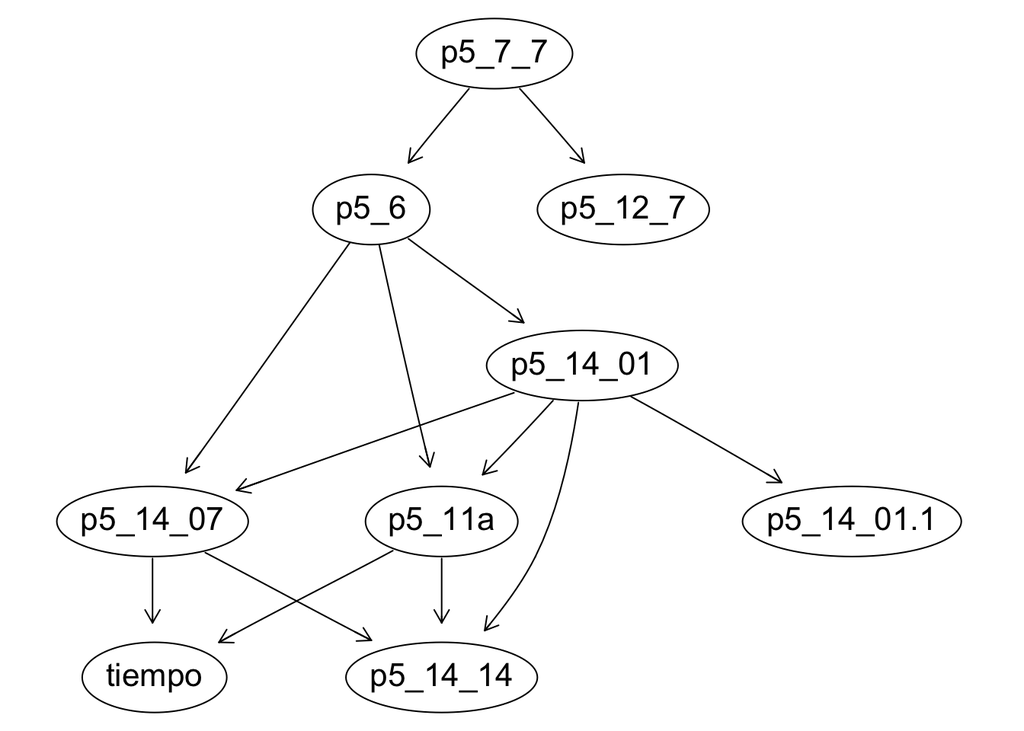

```r
graphviz.plot(dag, shape = "ellipse")
```

```r
bn <- bn.fit(dag, data = data)
```

1. ¿Cuál es la probabilidad de que el tiempo de viaje sea menor a 20 minutos, dado que su medio de transporte fue el automóvil?

```r
cpquery(bn, event = (tiempo < 20), evidence = (p5_14_01 == 1), n = 10^6)
```

```
[1] 0.2620653
```

2. ¿Cuál es la probabilidad de que los viajes en Ciudad de México se hagan en medios no motorizados (caminar o bicicleta)?

p5_14_14 = 1 (caminó) p5_14_07 = 1 (bicicleta)

p5_7_7 = 9 (Origen CDMX) p5_12_7 = 9 (Destino CDMX)

```r
cpquery(bn, event = (p5_14_14 == 1 | p5_14_07 == 1), evidence = (p5_7_7 == 9 & p5_12_7 == 9), n = 10^6)
```

```
[1] 0.6231272
```

4. ¿Cuál es la probabilidad de que el viaje del hogar a la escuela dure más de 60 minutos si la persona viaja en coche?

p5_6 == 1 (Origen Hogar) p5_11a == 2 (Destino Escuela)

p5_14_01 == 1 (Coche)

```r
cpquery(bn, event = (tiempo > 60), evidence = (p5_6 == 1 & p5_11a == 2 & p5_14_01 == 1), n = 10^6)
```

```
[1] 0.1562623
```

En la query #3 necesitamos otra dag relacionada con otro documento csv